# Decoding Virality: A Comparative Analysis of Trending Videos on YouTube and TikTok

Pythoneers

Author

Julia Schaffner, Varun Popli, Tatum Thomas, and Sophia Jukovich

Published

December 4, 2023

Abstract

*This report investigates the complex dynamics of content virality on prominent social media platforms, TikTok and YouTube. It systematically examines various factors influencing virality, including the characteristics that define viral content, the correlation between user interactions and content popularity, the time dynamics of content becoming viral, and the role of content descriptions in enhancing virality. Utilizing data from Kaggle and GitHub, the report employs a thorough data cleaning process and detailed analytical methods. The findings offer critical insights for content creators and digital marketers, providing a strategic understanding of how to tailor content for maximized engagement and visibility. This report not only sheds light on the nuances of social media virality but also proposes actionable recommendations for stakeholders, contributing significantly to the understanding of digital content strategy in the social media landscape.*.

## 1 Background / Motivation

In the digital age, ‘social media influencing’ has become an occupation of great importance—both in terms of money making capabilities and influence over society. But in order to get to that level of success, stars need to become stars. In other words, people need to ‘go viral.’ It is an elusive status that so many try to achieve. As such, we wanted to understand what makes content on social media go viral. Our experiences- whether it’s sharing a must-watch video with friends, being drawn into Youtube’s recommendation section, or witnessing viral tweets ignite global conversations - have made us wonder: Is there a formula to virality? Driven by this curiosity, we want to use our favorite platforms (TikTok and YouTube) to understand the factors that make content go viral.

## 2 Problem statement

Thus, the overarching question we aim to investigate is: What are the key factors and characteristics that drive content to achieve viral status on major social media platforms like TikTok, YouTube, and Twitter? This inquiry encompasses several dimensions:

Sophia Jukovich: What are the characteristics of ‘virality’? likes, comments, views, etc.) This question will explore the characteristics of ‘virality’ in both datasets. This data analysis will start with an explanation of what characteristics define virality and if some are weighted more heavily in considering how viral content is. Next, we will investigate whether the characteristics of virality vary based on what platform (YouTube or TikTok) the video was posted on.

Julia Schaffner: How does the public’s interaction (likes, dislikes, comments, and shares) correlate with content’s number of views? This question aims to explore how relationships between the number of likes, dislikes, comments, and shares of viral content affect its number of views. So, exploring ratios between likes, comments, and shares, as well as each level of interaction’s individual relationship with views differ. Additionally, looking at how disabling comments and/or ratings can affect the popularity of a video. By analyzing and comparing these results, we aim to draw conclusions about what the public seeks in trending content and how their interactions impact promotion/visibility of content by platforms.

Varun Popli: What factors shorten the ‘time of virality’ for content on the platforms? This question will explore if the data sports any trends in terms of what factors shorten what we are terming the ‘time of virality.’ This metric will be the length between when the content was posted and its trending date. This analysis will focus on first sorting the content by highest to lowest numbers of views for each set. Then, we will sort this set by shortest to longest ‘time of virality.’ Next, we will analyze the 50-100 content per set with the shortest ‘time of virality’ and see what/if any correlations between the content.

Tatum Thomas: How do descriptions enhance content’s exposure and potential to go viral? This question will explore how descriptions boost a video or post’s ranking on its respective platform and increase its chance of being discovered. By looking at description length (character count and word count), hashtag usage and link inclusion we will analyze correlations between these factors and content engagement. We will compare my results against metrics like views, likes, dislikes, and comments to gain a clear picture of the relationship between content description and content performance.

## 3 Data sources

The other open data source came from GitHub: - https://github.com/datares/TikTok_Famous/blob/main/Datasets/TikTok%20Video%20Data%20Collection/sug_users_vids_all.csv The dataset contains TikTok videos from across the entire platform in a .csv file. There are 9 continuous variables and 3 categorical variables. he dataset includes 41,675 videos. Some relevant variables include hashtags, song, video length, likes, shares, comments, views, and followers.

## 4 Stakeholders

The stakeholders in our project are content creators and digitals marketers & brands. By understanding the characteristics of virality, content creators can better tailor their posts to maximize reach and engagement. In addition, brands spend significant resources trying to ‘go viral’ to boost their visibility and sales. Insights from this project can provide them with a clearer roadmap on crafting impactful campaigns or collaborations that have a higher chance of gaining attention. The project can also benefit the everyday users of social media as it can offer them a behind-the-scenes look at why certain content becomes popular, helping them become more informed consumers of digital content.

## 5 Data quality check / cleaning / preparation

The only columns with missing values were non-numeric (descriptions on YouTube and songs on TikTok). Because of this and the size of our dataset, we decided to clean the data by deleting any rows with missing values.

After cleaning, we observed the following distributions:

### 5.1 Variable Distributions:

|  | Variable Name | Type | Total Values | Missing Values | Unique Values | Mean | Median | Min | Max | Standard Deviation |
| --- | --- | --- | --- | --- | --- | --- | --- | --- | --- | --- |
| 0 | n_likes | Continuous | 41675 | 0 | 12274 | 241863.413413 | 46100.0 | 0.0 | 22400000.0 | 685399.245962 |
| 1 | n_shares | Continuous | 41675 | 0 | 5544 | 2223.708506 | 146.0 | 0.0 | 727400.0 | 13284.89538 |
| 2 | n_comments | Continuous | 41675 | 0 | 6193 | 2419.285687 | 303.0 | 0.0 | 1200000.0 | 15426.913426 |
| 3 | hashtags | Categorical | 41675 | 0 | 17618 | None | None | None | None | None |
| 4 | n_plays | Continuous | 41675 | 0 | 11961 | 1702802.133557 | 326900.0 | 0.0 | 508800000.0 | 6437809.06722 |

|  | Variable Name | Type | Total Values | Missing Values | Unique Values | Mean | Median | Min | Max | Standard Deviation |
| --- | --- | --- | --- | --- | --- | --- | --- | --- | --- | --- |
| 0 | likes | Continuous | 40379 | 0 | 29664 | 74616.772753 | 18371.0 | 0.0 | 5613827.0 | 229617.243779 |
| 1 | views | Continuous | 40379 | 0 | 39927 | 2370838.716833 | 689597.0 | 549.0 | 225211923.0 | 7428515.361047 |
| 2 | dislikes | Continuous | 40379 | 0 | 8460 | 3508.121969 | 637.0 | 0.0 | 1643059.0 | 23174.860675 |
| 3 | comment_count | Continuous | 40379 | 0 | 13684 | 8287.396196 | 1874.0 | 0.0 | 1228655.0 | 34316.045734 |
| 4 | publish_time | Categorical | 40379 | 0 | 6172 | None | None | None | None | None |
| 5 | trending_date | Categorical | 40379 | 0 | 205 | None | None | None | None | None |
| 6 | description | Categorical | 40379 | 0 | 6901 | None | None | None | None | None |

### 5.2 Preparation:

1. Like-to-Ratio Column: In analysis 2, I studied like-to-comment ratios. In order to explore these ratios, I created new columns in both datasets in which the number of likes for each video was divided by the number of comments.
2. Time of Virality Column: In summary, this code loads YouTube data from a CSV file into a pandas DataFrame and then prints the contents of the DataFrame to the console. Then, it converts ‘trending_date’ to datetime format. The format is ‘YY.DD.MM’, so we need to rearrange it to ‘YY-MM-DD.’ for Analysis 3. Then I converted he ‘publish_time’ column to datetime format.’Publish_time’ includes time as well, so we will include it in the conversion. I then checked the first few rows to confirm the conversions. I then created a new column called ‘Time of Virality’ that is the difference in time between the trending date and publishing time. I then sorted the data from shortest to longest ‘Time of Virality’ values before extracting the numeric parts of the ‘Time of Virality’ column and conerting it to an integer. Lastly, I dropped all nonnumeric data points.
3. Data Aggregation: In analysis 2, I combined the datasets for a portion of the analysis by concatenating them.

## 6 Exploratory Data Analysis

### 6.1 Analysis 1

*By Sophia Jukovich*

I wanted to explore the characteristics of virality in both datasets and how they correlated with one another. In order to proceed, I had to identify videos that were deemed most popular across the two apps. In both the tiktok and youtube algorithms, the more views that a video has, the level of visibility is higher, therefore increasing its recommendation to others and overall popularity of the video. For this reason, I decided to name the number of views as my virality variable; essentially the more views a video has the more viral it is.

I started by identifying the goal of creating a dataset with the 100 most viewed videos in each dataset and eventually a combined one.

The first step I took was dropping any duplicates by ‘video_id’. I had previously followed through on creating a dataset without this step however I noticed that the top 4 videos were the same video. For this reason, and in order to get a set of 100 of the most viewed videos, I went back and dropped any duplicates before proceeding.

The next step I took was to create a ‘views_rank’ column in which I ranked the number of views from highest to lowest. Then, I sorted the ‘views_rank’ column so the number 1 ranked video would be on top. Finally I created the final dataset with only the top 100 observations.

I encountered a problem when I first tried making a combined dataset. If I wanted to make a dataset of the 100 most viewed videos across youtube and tiktok, the data would only contain one youtube observation. The second most viewed video in the youtube dataset contained less views than the 100th most viewed video in the tiktok dataset. For this reason, I kept the datasets separately knowing that the level of views in the tiktok dataset were higher than the youtube dataset.

For the youtube heatmap, I wanted to explore the correlation between various variables in the 100 viewed youtube videos dataset and the correlation between variables specifically correlated with views. I created the first heatmap to determine that the variables likes, dislikes, and comment_count most positively correlate with views. Then I created the second heatmap to establish that likes correlated most highly with views with a correlation coefficient of 0.53.

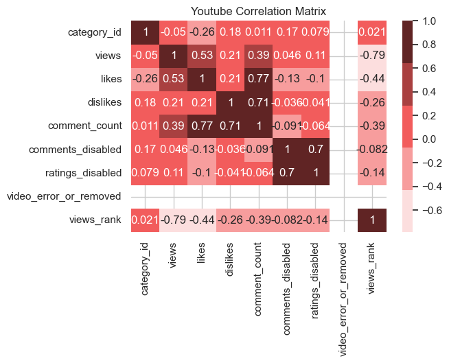

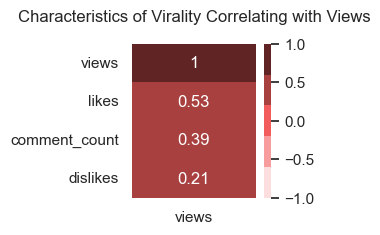

For the tiktok heatmap, I similarly wanted to explore the correlation in the entire dataset, then specifically variables that correlated positively with views. I found that in the entire dataset heatmap, the variables ‘n_comments’, ‘n_likes’, and ‘n_shares’ had the most positive correlations with views. When doing the single heatmap, I found that ‘n_comments’ had a correlation coefficient of 0.76.

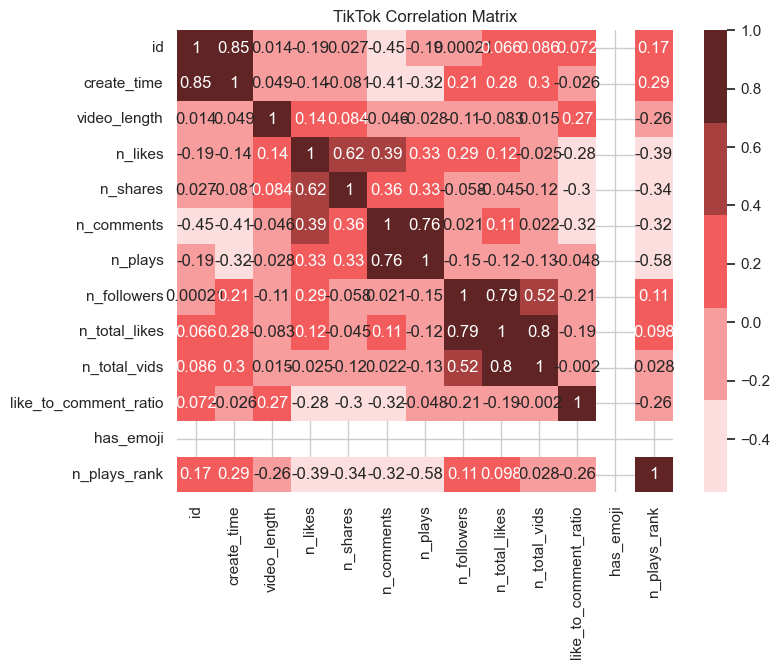

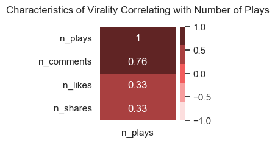

The determination from both of these heatmaps was that 1. Views and likes are more positively correlated on YouTube and 2. Views and comments were more positively correlated on TikTok.

In this part of the code, I wanted to do a comparison between the views, likes, and comments in both datasets. In order to visualize this I used two different scatter plots with a trendline. I plotted the views v.s. likes on youtube and tik tok without a trendline at first. The problem I ran into was similar to the one I had at the beginning where the range of tiktok views is at a much larger scale than the range of youtube views, and for this reason the youtube data was very clustered.

```
Stats for YouTube trendline: LinregressResult(slope=0.03741683633009211, intercept=140881.47099484637, rvalue=0.5278281125603275, pvalue=1.6698372480972645e-08, stderr=0.006082033676638222, intercept_stderr=87729.77955862979)
Stats for TikTok trendline: LinregressResult(slope=0.019148594444891174, intercept=6189250.2756414255, rvalue=0.33377310637190166, pvalue=0.0006897136985038614, stderr=0.005462916730286116, intercept_stderr=594980.4536751393)
```

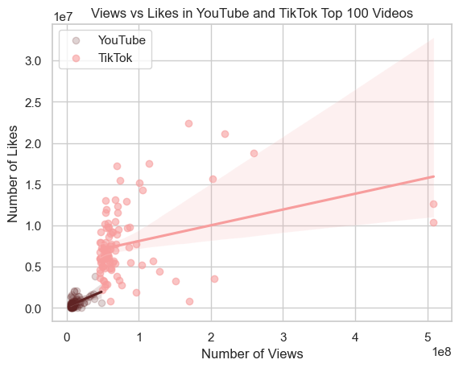

```
Slope of YouTube trendline: LinregressResult(slope=0.006229967953860189, intercept=10431.690209289358, rvalue=0.3920890714048781, pvalue=5.474709270419058e-05, stderr=0.0014765274484265626, intercept_stderr=21298.045102954406)
Slope of TikTok trendline: LinregressResult(slope=0.0019970685034583443, intercept=-61101.2124004193, rvalue=0.7576164838277883, pvalue=7.320411827566274e-20, stderr=0.0001737977334391128, intercept_stderr=18928.762672884168)
```

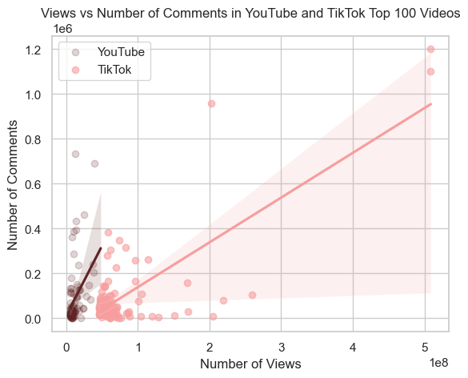

I realized it is important to compare the trendlines not to each other but to the line y = x because that line would have a correlation coefficient of 1. The addition of a scatterplot additionally contributes to understanding how user engagement metrics vary. For example, the tiktok dataset had more outliers than the youtube dataset which may have skewed the results. I felt however, that it was crucial to keep the outliers because these were the videos that were the most viral and had the most potential insight to what makes a video even more viral.

### 6.2 Analysis 2

*By Julia Schaffner*

In Analysis 2, we explore the question: How does the public’s interaction correlate with content’s number of views? To do this, we want to vizualize relationships between views and different ineraction metrics across platforms.

First, I created heatmaps for all of the interaction metrics and views to understand correlations between metrics and metrics against views.

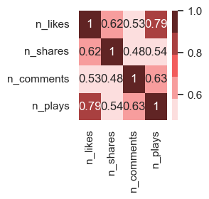

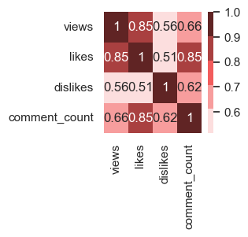

The heatmap analysis reveals compelling insights into the dynamics of viewership on TikTok and YouTube. A notable observation is the robust correlation between views and engagement metrics, specifically likes and comments, on both platforms.

This correlation underscores the pivotal role that engagement metrics play in driving overall viewership. While acknowledging the strong correlations identified, it is imperative to recognize that correlation does not imply causation. Therefore, a more in-depth investigation into the underlying factors shaping these observed relationships is essential. Additionally, considering platform-specific nuances and potential changes in algorithms over time will contribute to a comprehensive understanding of these dynamics.

To explore and compare the relationship of likes and comments with views across platforms, I made the following scatterplots, plotting both likes and comments against views on both TikTok and YouTube with trendlines.

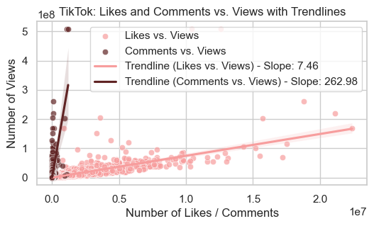

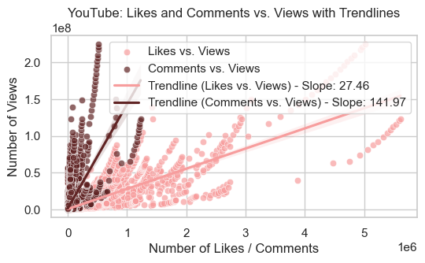

*TikTok Analysis*:

In the initial scatterplot depicting likes/comments versus views on TikTok, noteworthy trends emerge:

The slope of the comments versus views trendline is approximately 263. This implies that, on average, each comment corresponds to around 263 additional views for a TikTok video.

The trendline for likes versus views has a slope of about 7, indicating that, on average, each like is associated with approximately 7 more views.

The steeper trendline for comments compared to likes suggests that comments play a more influential role in driving views. Likes, on the other hand, demonstrate a more gradual and steady increase.

*YouTube Analysis*:

Examining the second scatterplot for likes/comments versus views on YouTube reveals similar trends:

The slope of the comments versus views trendline is around 142, signifying that, on average, each comment correlates with approximately 142 more views for a YouTube video.

The likes versus views trendline has a slope of about 27, indicating that, on average, each like is associated with approximately 27 more views.

Similar to TikTok, the steeper trendline for comments on YouTube suggests their stronger influence on views, while likes exhibit a more gradual impact.

Comparative Analysis:

By comparing the two platforms, it’s evident that a consistent trend is observed: views increase more rapidly concerning comments compared to likes. However, this trend is less pronounced on YouTube. The comments trendline is not as steep as TikTok’s, and the likes trendline is steeper.

Exploring Like-to-Comment Ratios:

Moving forward, I delved into like-to-comment ratio distributions and their relationship with views. To facilitate this exploration, I introduced a new column for like-to-comment ratios in each dataset. Initially, the distribution exhibited a severe right-skew for both platforms. To address this, I applied a logarithmic transformation, aiming to better visualize and compare the distributions across platforms. Given the focus on cross-platform comparison and not numerical interpretation, the use of a logarithmic transformation is considered valid.

In examining the interplay between likes, comments, and views, I initiated an exploration of the like-to-comment ratio, prompted by the observed high correlation between likes and comments on the heatmaps. This involved augmenting each dataset with a new column representing the like-to-comment ratio, computed by dividing the number of likes per video by its corresponding count of comments. To visually compare the distributions across TikTok and YouTube, I employed boxplots. However, the initial visualizations revealed a substantial right-skew on both platforms, complicating the extraction of meaningful insights. In response, I applied a logarithmic transformation to the data, strategically chosen to alleviate skewness and enhance visual interpretability without influencing numerical conclusions. It’s essential to clarify that this transformation was exclusively employed for facilitating a clear cross-platform comparison, emphasizing the visual aspects of the analysis. The goal was to gain insights into how like-to-comment ratios vary between TikTok and YouTube, contributing to a holistic exploration of engagement dynamics on these platforms.

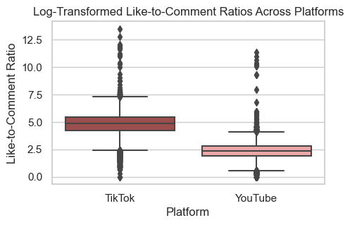

The primary insight derived from the boxplot analysis is a discernible disparity in like-to-comment ratios between TikTok and YouTube videos. Notably, TikTok videos exhibit a significantly higher average like-to-comment ratio compared to their counterparts on YouTube. This implies that, on average, TikTok videos tend to accumulate more likes relative to the number of comments compared to YouTube videos. Conversely, YouTube videos lean towards a higher incidence of comments compared to likes when juxtaposed with TikTok. The extent of this difference is underscored by the observation that the median like-to-comment ratio for YouTube videos falls approximately around the same point as TikTok’s Tukey’s (lower) fence. This marked contrast in engagement dynamics offers valuable insights into the distinctive patterns of user interaction and content appreciation on TikTok versus YouTube, contributing to a nuanced understanding of platform-specific engagement preferences.

In an effort to visualize the intricate relationship between like-to-comment ratios and views, I initially sought to create a barplot using the untransformed ratio column from the previous analysis. However, the wide range of ratios posed a challenge, making the barplot difficult to render and rendering it ineffective for drawing meaningful conclusions. To address this, I opted to bin the ratios, aiming to enhance data manageability and visualization clarity. My initial attempt to determine an optimal number of bins by incorporating lines in the barplot proved challenging due to the dataset’s substantial size. Consequently, I employed an alternative approach by testing various bin numbers on the final barplot. After experimentation, I settled on using 10 bins for both TikTok and YouTube. This choice not only facilitated easy visual comparison between the platforms but also revealed a clearer relationship between like-to-comment ratios and views. The strategic use of binning ultimately contributed to a more effective and insightful visualization of the nuanced dynamics between engagement ratios and viewership across TikTok and YouTube.

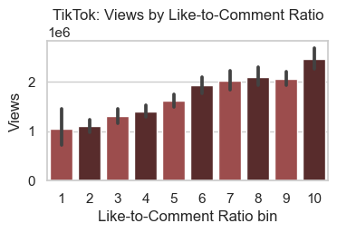

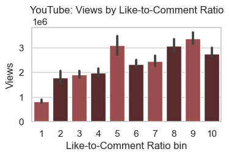

In examining the barplots illustrating the connection between like-to-comment ratios and views on TikTok and YouTube, distinct patterns emerge. On TikTok, a robust and consistently positive relationship unfolds, indicating that as likes surpass comments, a parallel increase in views ensues. This trend maintains a steady ascent. Conversely, the YouTube barplot reveals a similar yet noticeably weaker correlation. Noteworthy variations in peak values and intermittent periods of decreasing behavior set the YouTube visualization apart. In contrast to the uniform positive trend on TikTok, the YouTube data exhibits nuances that challenge the confidence in asserting a definitive relationship between like-to-comment ratios and views. If a relationship does indeed exist on YouTube, it is markedly weaker than the pronounced and steady connection observed on TikTok. This nuanced comparison underscores the platform-specific intricacies in the interplay between engagement ratios and viewership dynamics, shedding light on the divergent patterns characterizing TikTok and YouTube interactions.

### 6.3 Analysis 3

*By Varun Popli*

```
                  category_id     views     likes  dislikes  comment_count  \
category_id          1.000000 -0.168860 -0.174073 -0.047387      -0.086625
views               -0.168860  1.000000  0.848746  0.558108       0.655819
likes               -0.174073  0.848746  1.000000  0.514691       0.853380
dislikes            -0.047387  0.558108  0.514691  1.000000       0.623131
comment_count       -0.086625  0.655819  0.853380  0.623131       1.000000
Time_of_Virality    -0.032879 -0.012524 -0.015858 -0.007225      -0.012767

                  Time_of_Virality
category_id              -0.032879
views                    -0.012524
likes                    -0.015858
dislikes                 -0.007225
comment_count            -0.012767
Time_of_Virality          1.000000
```

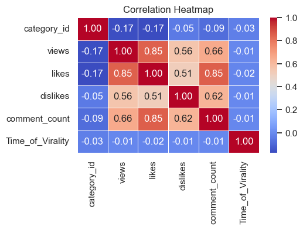

In this section of the code, a correlation matrix is computed for the numeric features in the ‘numeric_youtube_data’ DataFrame. The `corr()` method is applied to calculate the pairwise correlation coefficients between these features. The resulting correlation matrix is stored in the ‘correlation_matrix’ variable. Following the computation of the correlation matrix, a heatmap visualization is generated using the seaborn and matplotlib libraries. The heatmap provides a visual representation of the correlation values. This heat map shows little to no correlation between the other numeric variables and ‘Time of Virality.’ This is due to the fact that the correlation constants for the numeric variables and ‘Time of Virality’ are less than 0.03. This seems to indicate that there is no secret formula for going viral fast and that users who want to go viral should focus on making content that will get the most likes and views, even if it may not be the fastest.

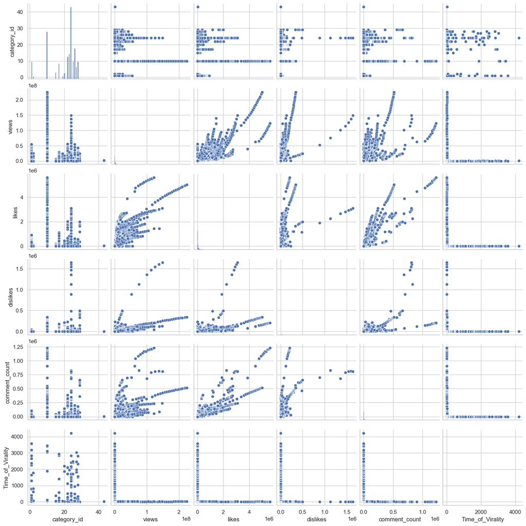

This code snippet utilizes seaborn’s pairplot function to create a matrix of scatterplots for the numeric features in the ‘numeric_youtube_data’ DataFrame. Each scatterplot represents the relationship between two numeric variables, and the diagonal shows the distribution of each variable. The sns.pairplot() function is called with ‘numeric_youtube_data’ as its argument, generating a grid of scatterplots. This grid allows for a quick visual inspection of potential patterns, correlations, and distributions among the numerical features. This pairplot shows many scatterplots tracking the correlation between the numeric variables. All of the graphs that track the correlation between ‘Time of Virality’ and another numeric variable show little to no correlation. This is due to the fact that there appears to be no relationship (positive or negative) in the data between ‘Time of Virality’ and any of the other numeric variables. This, like the heatmap above, seems to indicate that there is no secret formula for going viral fast and that users who want to go viral should focus on making content that will get the most likes and views, even if it may not be the fastest.

### 6.4 Analysis 4

*By Tatum Thomas*

In my exploratory analysis, I delve into understanding the impact of descriptions on a content’s exposure and viral potential. The central question guiding my analysis is: how descriptions contribute to a video’s virality on Tiktok & Youtube. To address this, I examine various description elements, including their length (both in terms of character and word count), the use of hashtags, and the inclusion of links. By analyzing the correlations between these descriptive elements and engagement metrics such as views, likes, shares, and comments, I aim to uncover insights into how the nature of a content’s description influences its overall performance.

Analyzing the Correlation Between YouTube Video Description Length and Viewer Engagement Metrics

I started with analyzing the Youtube dataset, where my first step was finding each video’s description length in the dataset, accounting for character and word counts. A statistical examination followed this to determine the correlation between description length and the number of views each video received. The core of this analysis involved creating a series of scatter plots with regression lines to visually explore the relationships between description length and critical engagement metrics: likes, dislikes, and comment counts. I plotted description length against the engagement metric for each metric, overlaying with a regression line to highlight trends.

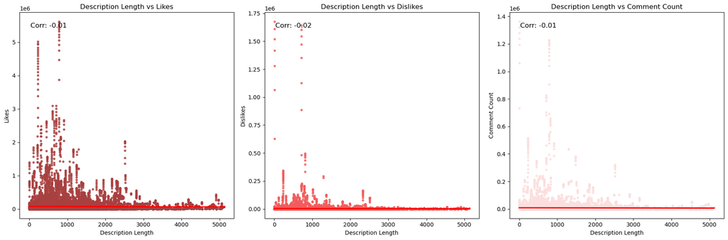

Investigating the Impact of Emojis in YouTube Video Descriptions

```
Count of videos with and without emojis:
False    31028
True      9351
Name: contains_emoji, dtype: int64
```

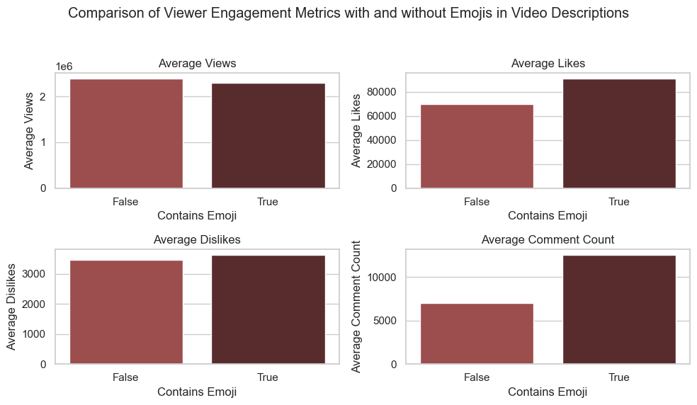

| contains_emoji | views | likes | dislikes | comment_count |
| --- | --- | --- | --- | --- |
| False | 2.390957e+06 | 69687.169879 | 3469.699852 | 6994.624436 |
| True | 2.304084e+06 | 90973.923645 | 3635.612234 | 12577.003957 |

This suggests that the presence of emojis in video descriptions may be associated with higher virality, as indicated by increased likes and increased comments. However, it’s important to note that views are slightly lower and dislikes are slightly higher for videos with emojis. This could indicate that emojis are used to target specific audiences or to engage viewers more.

Investigating the Impact of Links in YouTube Video Descriptions

In addition to emojis being in a youtube video description, I also examined the influence of including a hyperlink in a youtube description. I created a custom function contains_link that checks whether a given string contains any web links. The function searches for common link prefixes such as ‘http://’, ‘https://’, or ‘www.’ within the description text. Videos were categorized into two groups: those with links in their descriptions and those without.

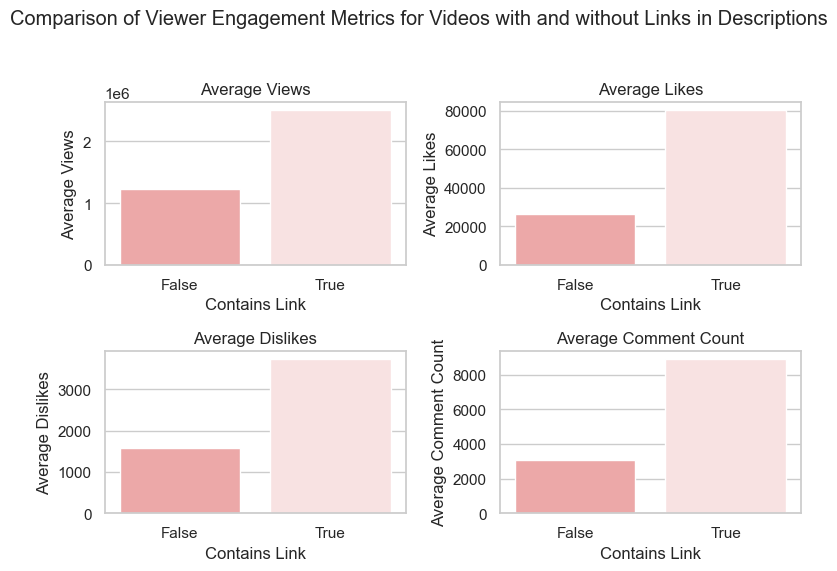

| contains_link | views | likes | dislikes | comment_count |
| --- | --- | --- | --- | --- |
| False | 1.234420e+06 | 26587.030289 | 1571.971077 | 3069.014575 |
| True | 2.509496e+06 | 80477.020590 | 3744.357341 | 8924.106035 |

```python
#| echo: false
# Check if a given string (s) contains a hyperlink
def contains_link(s):
    return 'http://' in str(s) or 'https://' in str(s) or 'www.' in str(s)
youtube_data['contains_link'] = youtube_data['description'].apply(contains_link)

# Group by 'contains_link' and calculate mean values for engagement metrics
grouped_data_link = youtube_data.groupby('contains_link')[['views', 'likes', 'dislikes', 'comment_count']].mean()

sns.set(style="whitegrid")

fig, axes = plt.subplots(2, 2, figsize=(8, 6))
fig.suptitle('Comparison of Viewer Engagement Metrics for Videos with and without Links in Descriptions')

colors = ["#f79d9d", "#fcdede"]

sns.barplot(ax=axes[0, 0], x=grouped_data_link.index, y=grouped_data_link['views'], palette=colors)
axes[0, 0].set_title('Average Views')
axes[0, 0].set_xlabel('Contains Link')
axes[0, 0].set_ylabel('Average Views')


sns.barplot(ax=axes[0, 1], x=grouped_data_link.index, y=grouped_data_link['likes'], palette=colors)
axes[0, 1].set_title('Average Likes')
axes[0, 1].set_xlabel('Contains Link')
axes[0, 1].set_ylabel('Average Likes')


sns.barplot(ax=axes[1, 0], x=grouped_data_link.index, y=grouped_data_link['dislikes'], palette=colors)
axes[1, 0].set_title('Average Dislikes')
axes[1, 0].set_xlabel('Contains Link')
axes[1, 0].set_ylabel('Average Dislikes')


sns.barplot(ax=axes[1, 1], x=grouped_data_link.index, y=grouped_data_link['comment_count'], palette=colors)
axes[1, 1].set_title('Average Comment Count')
axes[1, 1].set_xlabel('Contains Link')
axes[1, 1].set_ylabel('Average Comment Count')

plt.tight_layout(rect=[0, 0.03, 1, 0.95])
plt.show()
grouped_data_link = youtube_data.groupby('contains_link')[['views', 'likes', 'dislikes', 'comment_count']].mean()

grouped_data_link
```

My analysis revealed that including hyperlinks in YouTube video descriptions has a notable impact on viewer engagement metrics. Videos with hyperlinks in their descriptions tend to receive significantly more views, with an average of approximately 2,509,496 views, compared to approximately 1,234,420 views for videos without hyperlinks. Additionally, videos with hyperlinks receive substantially more likes (around 80,477) and generate more comments (approximately 8,924) on average. However, the videos with hyperlinks do generate significantly more dislikes (an average of around 3,744 compared to 1,571 in those without hyperlinks). This suggests that hyperlinks positively influence viewer engagement, attracting more views, likes, and comments (and more dislikes), making them a valuable addition to video descriptions for content creators in order to increase overall engagement for viewers.

Analyzing the Relationship Between TikTok Hashtag Length and Viewer Engagement Metrics

I then proceeded to analyze the TikTok dataset, following a similar approach. However, it’s important to note that in the dataset used for TikTok videos, the description category consists of hashtags, without additional features as found in YouTube descriptions. To investigate the potential impact of virality, I initiated the analysis by assessing the length of these hashtag-only descriptions, exploring whether including more hashtags could influence the engagement and reach of TikTok videos. I converted the ‘hashtags’ column from a string representation into an actual list and counted the number of hashtags used in each post. I then categorized these counts into bins ranging from 0 to 50, in increments of 5, allowing us to segment the data into groups reflecting the volume of hashtags used. Subsequently, I aggregated the data within these bins to determine the mean values of likes and comments, providing a clear view of engagement.

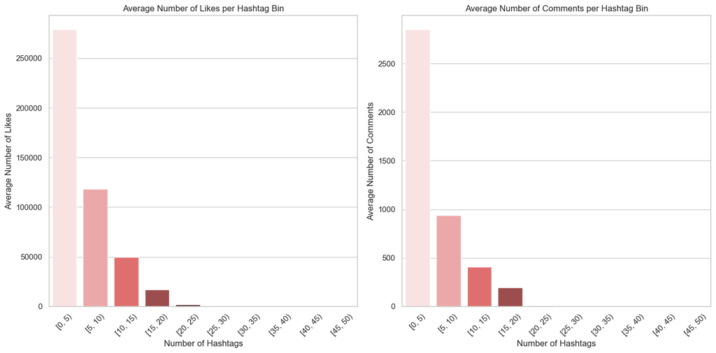

Investigating the Impact of Emojis in Tik Tok Video Descriptions

I then investigated the role of emojis within hashtags and their potential impact on the number of likes that TikTok videos receive. A custom regular expression pattern was utilized to identify emojis in hashtags, and a function was created to determine the presence of emojis within the hashtags of each video. A box plot was then crafted to visually compare the distribution of likes for videos with emojis in their hashtags against those without. Given the wide range of likes, a logarithmic scale was applied to the y-axis to allow a more discernible comparison across orders of magnitude in like counts.

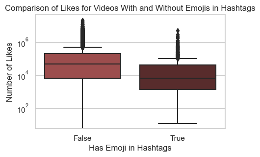

## 7 Conclusions

In the ever-evolving landscape of social media, achieving virality on Tiktok and Youtube requires a nuanced and data-driven approach. This set of recommendations is designed to guide our stakeholders in crafting content strategies that are not only practical but also tailored to the unique characteristics of each platform. By focusing on authentic engagement, content creation, and strategic adaptability, these recommendations aim to foster sustainable virality and long-term audience engagement.

## 8 Recommendations to stakeholder(s)

*Targeting Tiktok Virality: Stimulate Comments* When crafting content for TikTok, prioritize elements that prompt audience engagement through comments. We found that TikTok’s algorithm likely places significant weight on comments, making them a key factor in determining a video’s virality. Encouraging viewers to share their thoughts, opinions, or participate in challenges can foster a sense of community and increase the likelihood of your content being pushed to a wider audience.

*Optimizing Youtube Virality: Prioritize Likes* On YouTube, the number of likes a video receives plays a crucial role in its visibility and reach. Tailor your content to evoke positive reactions from viewers, prompting them to hit the “like” button. Quality content that resonates with your audience and elicits a favorable response is more likely to be recommended by YouTube’s algorithm, contributing to increased likes and overall virality.

*Maintain Like-to-Comment Balance on TikTok* While encouraging comments on TikTok is essential, it’s equally important to strike a balance with likes. Excessive comments relative to likes may signal a lack of broad appeal to the algorithm, potentially leading to decreased visibility. Aim for a harmonious like-to-comment ratio by fostering both forms of engagement. This approach ensures your content is not only sparking conversations but also receiving the positive feedback reflected in likes.

*Gradual Virality Approach: Avoid Fast-tracking* Resist the urge to prioritize rapid virality over content quality. Instead, focus on creating content that excels in terms of likes, comments, and views over time. The highest levels of virality are often achieved through sustained audience engagement and resonance. By delivering consistent, high-quality content, you increase the chances of long-term success and audience loyalty rather than relying on quick, short-lived spikes in virality.

*Strategic Emoji Use Across Platforms* Leverage emojis strategically to enhance engagement on YouTube, where they can convey tone, add personality, and encourage interaction in the comments section. However, exercise caution on TikTok, as an excessive use of emojis might be perceived as spammy and could deter viewers. Understand the unique audience behavior on each platform and tailor your emoji strategy accordingly to maximize positive interactions and contribute to the overall virality of your content.